# QAnon at Denison

2021-04-12

“I believe that there is some sort of sex trafficking ring that the elites are involved in. Does that mean I believe in QAnon?”

This is part of a conversation about QAnon I had with a close friend. As someone actively involved in many social justice issues, he was terrified of the possibility that he agreed with the QAnon conspiracy theory given its support for Trump and a whole host of other issues. But this is just the thing – the tendrils of the conspiracy theory have extended throughout society, whether we affirm it consciously as QAnon or not.

Recently, I wrote another post (found on my [website](https://jacob-dennen.netlify.app/post/qanon-millenials-and-gen-z/) and [One Twenty Seven](https://onetwentyseven.blog/2021/03/17/qanon-millennials-and-gen-z/)) based on data gathered from a national survey about how QAnon support varies by generation. Despite having the lowest levels of agreement, at least one out of every three Boomers and Zoomers (Gen Z) agreed with QAnon. When I saw how widespread QAnon support was among Gen Z, I had to ask, how widespread is QAnon support among Denison students?

Fortunately, I can answer this question. In March 2021, I was able to collaborate with a few other students on a survey that got sent out to the entire student body. To gauge QAnon support we asked respondents whether they agreed that,

> “Within the upper reaches of government, media, and finance, a secretive group of elites are thwarting Donald Trump’s efforts at reform, fomenting street violence, and engaging in child trafficking and other crimes.”

The respondents were then given the options “Strongly Disagree”, “Somewhat Disagree”, “Neither Disagree nor Agree”, “Somewhat Agree”, or “Strongly Agree”. Turns out nearly one in every five students (18%) chose either “Strongly Agree” or “Somewhat Agree” with QAnon views.

We can see in the graph below how Denison students view QAnon. More than half (51%) of Denisonians actively disagree with Qanon with 36% strongly disagreeing and 15% somewhat disagreeing. Another 31% don’t really have an opinion or simply do not know. The remaining 18% actively agree with QAnon with 13% somewhat agreeing and 5% strongly agreeing. While it is good that the percentage of students who actively agree is relatively low, it is still worrisome that 49% of the respondents found enough truth in the statement to not say that they disagree.

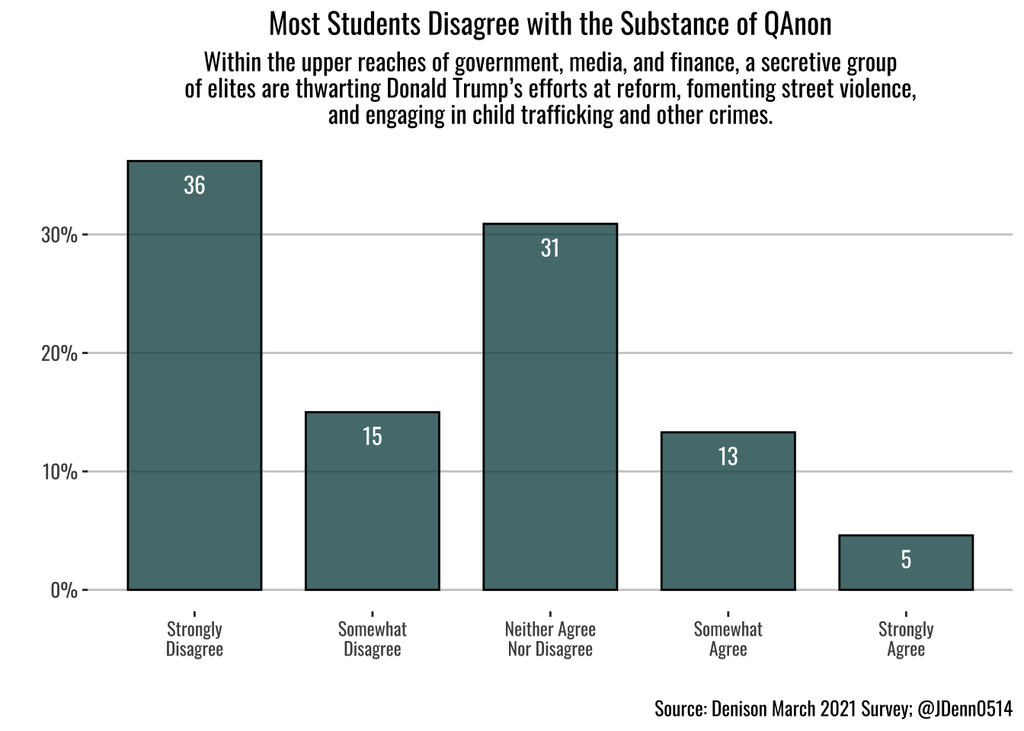

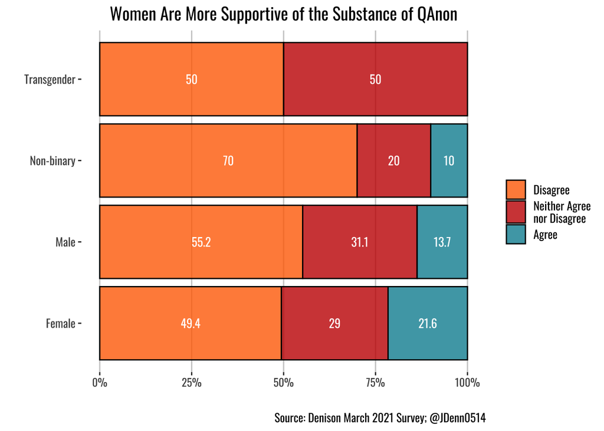

We just saw how support for QAnon among genders flipped at Denison, let’s see if Whites vs POC does the same thing.[^2] Again, contrary to the results from a national survey, POC at Denison are more supportive of QAnon than Whites. While 15.5% of Whites actively agree with QAnon, 26.1% of POC agree with QAnon. Furthermore, 57.9% of Whites actively disagree with QAnon with 26.5% choosing “neither agree nor disagree”. For POC, the number who disagree drops down to 33.9% and the number who neither agree nor disagree increases to 40%.

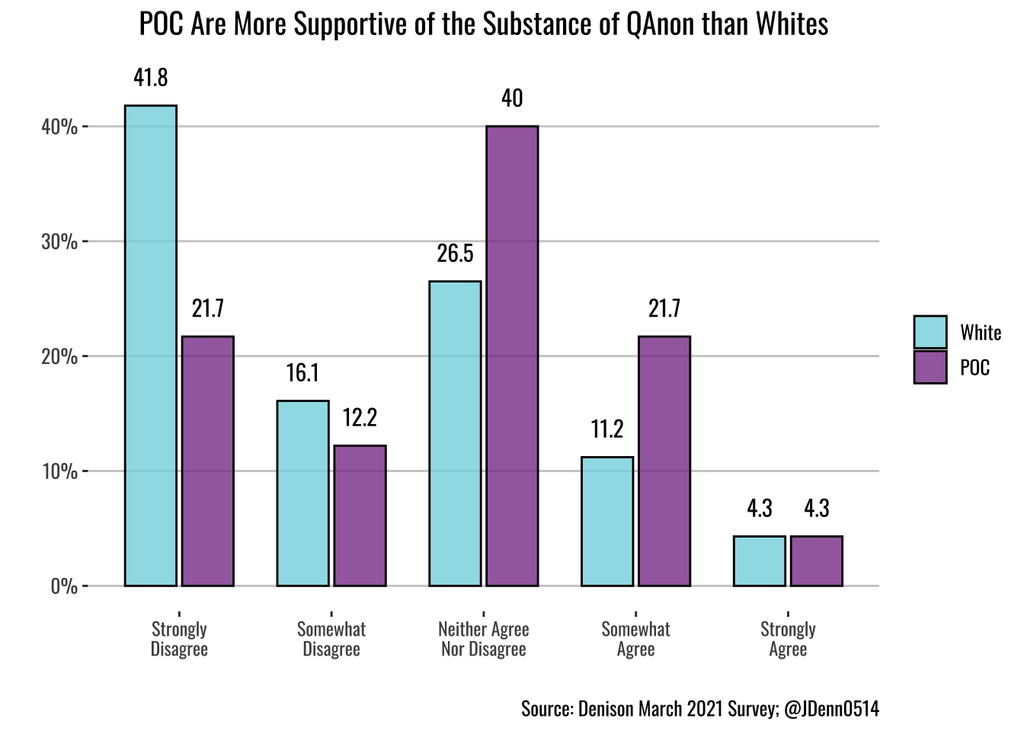

As I am sure you all are thinking, at first glance this doesn’t make much sense. It wasn’t until I began looking for a question that could help explain this that it finally started to make more sense. We can see below that feelings towards US democracy have a strong impact on whether POC agree with QAnon. Given the strong anti-establishment and anti-elite rhetoric of QAnon beliefs this should not be very surprising. When people are embarrassed or frustrated with something, especially something like the way the government is working or the economy, they are likely to look for a scapegoat to blame. This is where QAnon comes into play and why it is so successful. QAnon scapegoats the elites and claims that they are the ones not allowing reforms to happen. This does two things: (1) It takes advantage of the anti-elite sentiment that already exists; and (2) It provides people with a scapegoat.

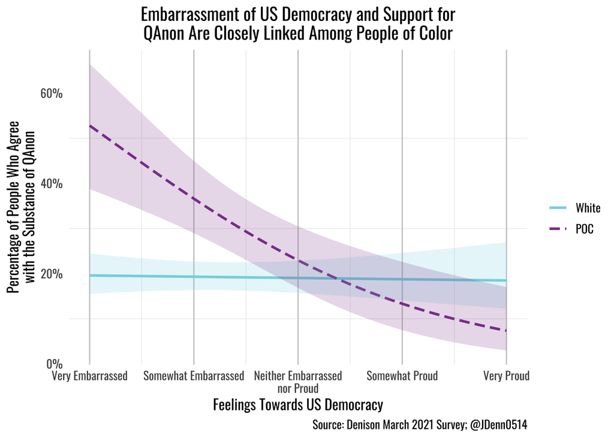

QAnon is a very dangerous conspiracy theory that has a history of fomenting violence. Throughout this post I looked at how prevalent the conspiracy theory is among Denison students. Contrary to the rest of the country, women and POC at Denison are more supportive of QAnon than men and Whites. As Dr. Paul A. Djupe said, “QAnon style beliefs are like water that fill crevasses of trust between mass and elites.” For many in the general public, QAnon fills the gap in trust that people feel towards mainstream media, the “radical left”, and “the swamp”. For students at Denison, some QAnon beliefs likely play on the mistrust people have towards the elites. When I questioned my friend about how he could believe that the elites ran a secret sex trafficking ring, he asked me “How do you know there isn’t one? Are they really trustworthy enough to believe what they say?”

[^1]: It is important to note that there were only two respondents who identified as transgender and ten who identified as non-binary
[^2]: It is important to note that this is an imperfect measurement in part because of the small sample size but also because different people of color have different experiences. Nevertheless, it is still telling how POC differ from Whites.